# Ch4数据预处理

数据预处理

```python
import warnings
warnings.filterwarnings('ignore')
```

## 利用Pandas进行数据清洗

### 检测与处理缺失值

#### 【例4-1】利用isnull检测缺失值。

```python
import pandas as pd
import numpy as np
string_data = pd.Series(['aardvark', 'artichoke', np.nan, 'avocado'])
print(string_data)
string_data.isnull() #isnull（）检测缺失值
#string_data.notnull()
```

```
0     aardvark
1    artichoke
2          NaN
3      avocado
dtype: object
```

```
0    False
1    False
2     True
3    False
dtype: bool
```

#### 【例4-2】Series中的None值处理。

文不对题

```python
string_data = pd.Series(['aardvark', 'artichoke',np.nan, 'avocado'])
string_data.isnull()
```

```
0    False
1    False
2     True
3    False
dtype: bool
```

#### 【例4-3】利用isnull().sum()统计缺失值。

```python
df = pd.DataFrame(np.arange(12).reshape(3,4),columns = ['A','B','C','D'])
df.iloc[2,:] = np.nan  #修改第2行所有数据为空
df[3] = np.nan  #设置第3列所有数据为空
#df.iloc[:,3] = np.nan
print(df)
df.isnull().sum() #统计每列缺失值个数
```

```
     A    B    C    D   3
0  0.0  1.0  2.0  3.0 NaN
1  4.0  5.0  6.0  7.0 NaN
2  NaN  NaN  NaN  NaN NaN
```

```
A    1
B    1
C    1
D    1
3    3
dtype: int64
```

#### 【例4-4】用info方法查看DataFrame的缺失值。

```python
df.info()
```

```
<class 'pandas.core.frame.DataFrame'>
RangeIndex: 3 entries, 0 to 2
Data columns (total 5 columns):
 #   Column  Non-Null Count  Dtype
---  ------  --------------  -----
 0   A       2 non-null      float64
 1   B       2 non-null      float64
 2   C       2 non-null      float64
 3   D       2 non-null      float64
 4   3       0 non-null      float64
dtypes: float64(5)
memory usage: 248.0 bytes
```

### 缺失值的处理

#### 删除缺失值

##### 【例4-5】Series的dropna用法。

删除有缺失值，返回一个仅含非空数据和索引值的Series dropna(axis=0,how='any',thresh=None,subset=None,inplace=False)

axis: default 0指行,1为列 how: {‘any’, ‘all’}, default ‘any’指删除带缺失值的所有行;'all’指某行全是缺失值才删除 thresh: 阈值设定，int,保留含有int个以上非空值的行列 ubset: 对特定的列进行缺失值删除处理，如subset['a','b'],即丢弃子列a,b中含有缺失值的行 inplace: 默认false，True表示直接在原数据上更改，无返回值

```python
from numpy import nan as NA
data = pd.Series([1, NA, 3.5, NA, 7])
print(data)

print(data.dropna( ))
```

```
0    1.0
1    NaN
2    3.5
3    NaN
4    7.0
dtype: float64
0    1.0
2    3.5
4    7.0
dtype: float64
```

##### 【例4-6】布尔型索引选择过滤非缺失值。

```python
not_null = data.notnull()#非空则为True
print(not_null)
print(data[not_null])
```

```
0     True
1    False
2     True
3    False
4     True
dtype: bool
0    1.0
2    3.5
4    7.0
dtype: float64
```

##### 【例4-7】DataFrame对象的dropna默认参数使用。

```python
from numpy import nan as NA
data = pd.DataFrame([[1., 5.5, 3.], [1., NA, NA],[NA, NA, NA],
[NA, 5.5, 3.]])
print(data)
cleaned = data.dropna() #how默认any，有则删除
print('删除缺失值后的：\n',cleaned)
```

```
     0    1    2
0  1.0  5.5  3.0
1  1.0  NaN  NaN
2  NaN  NaN  NaN
3  NaN  5.5  3.0
删除缺失值后的：
      0    1    2
0  1.0  5.5  3.0
```

##### 【例4-8】传入参数all。

```python
data = pd.DataFrame([[1., 5.5, 3.], [1., NA, NA],[NA, NA, NA],
[NA, 5.5, 3.]])
print(data)
data.dropna(how='all') #删除全为NA的行
```

```
     0    1    2
0  1.0  5.5  3.0
1  1.0  NaN  NaN
2  NaN  NaN  NaN
3  NaN  5.5  3.0
```

|  | 0 | 1 | 2 |
| --- | --- | --- | --- |
| 0 | 1.0 | 5.5 | 3.0 |
| 1 | 1.0 | NaN | NaN |
| 3 | NaN | 5.5 | 3.0 |

##### 【例4-9】dropna中的axis参数应用。

```python
data = pd.DataFrame([[1., 5.5, NA], [1., NA, NA],[NA, NA, NA], [NA, 5.5, NA]])
print(data)
data.dropna(axis = 1, how = 'all') #删除全为NA的列
```

```
     0    1   2
0  1.0  5.5 NaN
1  1.0  NaN NaN
2  NaN  NaN NaN
3  NaN  5.5 NaN
```

|  | 0 | 1 |
| --- | --- | --- |
| 0 | 1.0 | 5.5 |
| 1 | 1.0 | NaN |
| 2 | NaN | NaN |
| 3 | NaN | 5.5 |

##### 【例4-10】dropna中的thresh参数应用。

```python
df = pd.DataFrame(np.random.randn(7, 3))
df.iloc[:4, 1] = NA
df.iloc[:2, 2] = NA
print(df)
df.dropna(thresh=2)  #删除NA值>=2的行
```

```
          0         1         2
0 -0.752614       NaN       NaN
1 -0.508098       NaN       NaN
2  1.365423       NaN  0.075676
3  0.187431       NaN -1.592076
4  0.374522 -2.354622 -0.222633
5  0.301744 -0.984287 -1.258589
6  0.121545  1.543539  0.557861
```

|  | 0 | 1 | 2 |
| --- | --- | --- | --- |
| 2 | 1.365423 | NaN | 0.075676 |
| 3 | 0.187431 | NaN | -1.592076 |
| 4 | 0.374522 | -2.354622 | -0.222633 |
| 5 | 0.301744 | -0.984287 | -1.258589 |
| 6 | 0.121545 | 1.543539 | 0.557861 |

#### 填充缺失值

数值型：均值、中位数或众数等

类别型：众数

函数：Pandas库 fillna(value=None, method=None, axis=None, inplace=False, limit=None)

method参数的取值 ： {‘pad’, ‘ffill’,‘backfill’, ‘bfill’, None}, default None

pad/ffill：用前一个非缺失值去填充该缺失值

backfill/bfill：用下一个非缺失值填充该缺失值

None：指定一个值去替换缺失值（缺省默认这种方式）

limit参数：（对于前向和后向填充）可以连续填充的最大个数

##### 【例4-11】通过字典形式填充缺失值。

```python
df = pd.DataFrame(np.random.randn(5,3))
df.loc[:3,1] = NA
df.loc[:2,2] = NA
print(df)
df.fillna({1:0.88,2:0.66}) #通过字典形式填充缺失值
```

```
          0         1         2
0  1.057023       NaN       NaN
1 -2.345032       NaN       NaN
2  0.229426       NaN       NaN
3 -1.273790       NaN  0.132312
4  0.182587 -0.629525  0.390275
```

|  | 0 | 1 | 2 |
| --- | --- | --- | --- |
| 0 | 1.057023 | 0.880000 | 0.660000 |
| 1 | -2.345032 | 0.880000 | 0.660000 |
| 2 | 0.229426 | 0.880000 | 0.660000 |
| 3 | -1.273790 | 0.880000 | 0.132312 |
| 4 | 0.182587 | -0.629525 | 0.390275 |

##### 【例4-12】fillna中method的应用。

```python
df = pd.DataFrame(np.random.randn(6, 3))
df.iloc[2:, 1] = NA
df.iloc[4:, 2] = NA
print(df)
df.fillna( method = 'ffill') #填充该列前一个非空
#df.fillna(axis=1,method = 'ffill') #填充该行前一个非空
```

```
          0         1         2
0  1.225226  1.142343  0.562057
1 -0.094568  0.263632 -1.612528
2  1.356934       NaN -1.101889
3 -0.994060       NaN -0.552843
4  0.409639       NaN       NaN
5 -1.530717       NaN       NaN
```

|  | 0 | 1 | 2 |
| --- | --- | --- | --- |
| 0 | 1.225226 | 1.142343 | 0.562057 |
| 1 | -0.094568 | 0.263632 | -1.612528 |
| 2 | 1.356934 | 0.263632 | -1.101889 |
| 3 | -0.994060 | 0.263632 | -0.552843 |
| 4 | 0.409639 | 0.263632 | -0.552843 |
| 5 | -1.530717 | 0.263632 | -0.552843 |

##### 【例4-13】用Series的均值填充。

```python
data = pd.Series([1., NA, 3.5, NA, 7])
data.fillna(data.mean())
```

```
0    1.000000
1    3.833333
2    3.500000
3    3.833333
4    7.000000
dtype: float64
```

##### 【例4-14】DataFrame中用均值填充。

```python
df = pd.DataFrame(np.random.randn(4, 3))
df.iloc[2:, 1] = NA
df.iloc[3:, 2] = NA
print(df)
df[1] = df[1].fillna(df[1].mean())
print(df)
```

```
          0         1         2
0 -1.268905 -0.214821  0.328274
1 -0.871878 -0.967787  1.581918
2  0.059917       NaN  0.427219
3  0.313976       NaN       NaN
          0         1         2
0 -1.268905 -0.214821  0.328274
1 -0.871878 -0.967787  1.581918
2  0.059917 -0.591304  0.427219
3  0.313976 -0.591304       NaN
```

### 数据值替换

Pandas库的replace()函数

#### 【例4-15】replace替换数据值。

```python
data = {'姓名':['张三','小明','马芳','国志'],'性别':['0','1','0','1'],
'籍贯':['北京','甘肃','','上海']}
df = pd.DataFrame(data)
print(df)
df = df.replace('','不详')
print(df)
```

```
   姓名 性别  籍贯
0  张三  0  北京
1  小明  1  甘肃
2  马芳  0
3  国志  1  上海
   姓名 性别  籍贯
0  张三  0  北京
1  小明  1  甘肃
2  马芳  0  不详
3  国志  1  上海
```

#### 【例4-16】replace传入列表实现多值替换。

```python
df = df.replace(['不详','甘肃'],['兰州','兰州']) #第一个list为被替换值，第二个list为替换值
print(df)
```

```
   姓名 性别  籍贯
0  张三  0  北京
1  小明  1  兰州
2  马芳  0  兰州
3  国志  1  上海
```

#### 【例4-17】 replace传入字典实现多值替换。

```python
df = df.replace({'1':'男','0':'女'}) #数据一致性
print(df)
```

```
   姓名 性别  籍贯
0  张三  女  北京
1  小明  男  兰州
2  马芳  女  兰州
3  国志  男  上海
```

### 利用函数或映射进行数据转换

自定义转换函数，再通过map( )方法进行实现

#### 【例4-18】map方法映射数据。

```python
data = {'姓名':['张三','小明','马芳','国志'],'性别':['0','1','0','1'],
'籍贯':['北京','兰州','兰州','上海']}
df = pd.DataFrame(data)
df['成绩'] = [58,86,91,78]
print(df)
def grade(x):             #定义转换函数grade
    if x>=90:
        return '优'
    elif 70<=x<90:
        return '良'
    elif 60<=x<70:
        return '中'
    else:
        return '差'
df['等级'] = df['成绩'].map(grade)
print(df)
```

```
   姓名 性别  籍贯  成绩
0  张三  0  北京  58
1  小明  1  兰州  86
2  马芳  0  兰州  91
3  国志  1  上海  78
   姓名 性别  籍贯  成绩 等级
0  张三  0  北京  58  差
1  小明  1  兰州  86  良
2  马芳  0  兰州  91  优
3  国志  1  上海  78  良
```

### 异常值检测

#### 散点图方法

##### 【例4-19】利用散点图检测异常值。

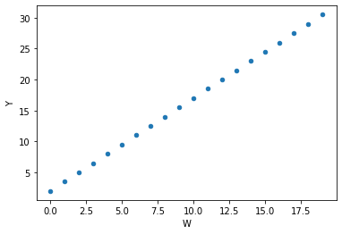

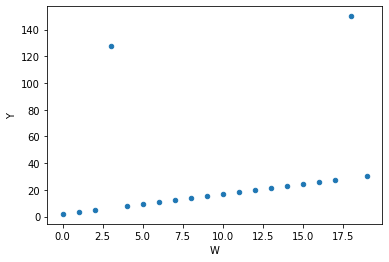

```python
import pandas as pd

wdf = pd.DataFrame(np.arange(20),columns = ['W'])
wdf['Y'] = wdf['W']*1.5+2
wdf.plot(kind = 'scatter',x = 'W',y = 'Y')
wdf.iloc[3,1] = 128
wdf.iloc[18,1] = 150
wdf.plot(kind = 'scatter',x = 'W',y = 'Y')
```

#### 箱线图方法

利用箱线图进行异常值检测时，根据经验，将最大（最小）值设置为与四分位数值间距为1.5个IQR（IQR=Q3-Q2）的值，即min=Q1-1.5IQR，max=Q3+1.5IQR，小于min和大于max的值被认为是异常值。

##### 【例4-20】利用箱线图分析异常值。

[output not shown]

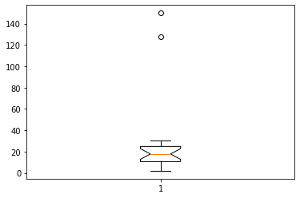

```python
import matplotlib.pyplot as plt
plt.boxplot(wdf['Y'].values,notch = True)
```

#### 3σ法则

##### 【例4-21】利用3σ法则检测异常值。

```python
def outRange(S):
    blidx = (S.mean()-3*S.std()>S)|(S.mean()+3*S.std()<S)
    idx = np.arange(S.shape[0])[blidx]
    outRange = S.iloc[idx]
    return outRange
outier = outRange(wdf['Y'])
outier
```

```
18    150.0
Name: Y, dtype: float64
```

## 数据集成

### 实体识别

注意集成时实体对应是其中的关键问题！

### 数据冗余与相关分析

#### 【例4-22】利用Python计算属性间的相关性。

```python
import pandas as pd
import numpy as np
# a = [np.random.randint(0, 100) for a in range(20)]
# b = [random.randint(0, 100) for a in range(20)]
a=[47, 83, 81, 18, 72, 41, 50, 66, 47, 20, 96, 21, 16, 60, 37, 59, 22, 16, 32, 63]
b=[56, 96, 84, 21, 87, 67, 43, 64, 85, 67, 68, 64, 95, 58, 56, 75, 6, 11, 68, 63]
data=np.array([a, b]).T
dfab = pd.DataFrame(data, columns=['A', 'B'])
print(dfab)
print('属性A和B的协方差：',dfab.A.cov(dfab.B))
print('属性A和B的相关系数：',dfab.A.corr(dfab.B))
```

```
     A   B
0   47  56
1   83  96
2   81  84
3   18  21
4   72  87
5   41  67
6   50  43
7   66  64
8   47  85
9   20  67
10  96  68
11  21  64
12  16  95
13  60  58
14  37  56
15  59  75
16  22   6
17  16  11
18  32  68
19  63  63
属性A和B的协方差： 310.2157894736842
属性A和B的相关系数： 0.49924871046524394
```

### 元组重复

利用Pandas.DataFrame.duplicates方法检测重复的数据

利用Pandas.DataFrame.drop_duplicates方法删除重复的数据

```python
db=[[1,2,3],[1,2,2],[1,2,3]]
df=pd.DataFrame(db)
print(df)
df.duplicated()
df.drop_duplicates()
```

```
   0  1  2
0  1  2  3
1  1  2  2
2  1  2  3
```

|  | 0 | 1 | 2 |
| --- | --- | --- | --- |
| 0 | 1 | 2 | 3 |
| 1 | 1 | 2 | 2 |

### 利用Pandas合并数据

#### 使用Merge（）函数进行数据合并

DataFrame.merge(left,right, how='inner', on=None, left_on=None, right_on=None, left_index=False, right_index=False, sort=False, suffixes=('_x', '_y'), copy=True, indicator=False, validate=None)

left 参与合并的左侧df

right 参与合并的右侧df

how='inner' 连接方法 'left',right,outer

on=None 指定连接的列/属性

left_on=None 左侧df用于连接键的列

right_on=None 右侧df用于连接键的列

left_index=False 左侧df行index作为连接键

right_index=False 右侧df行index作为连接键

sort=False 合并后对数据排序

suffixes=('_x', '_y') 修改重复名

https://pandas.pydata.org/pandas-docs/stable/reference/api/pandas.DataFrame.merge.html?highlight=merge#pandas.DataFrame.merge

##### 【例4-23】merge的默认合并数据。

```python
price = pd.DataFrame({'fruit':['apple','grape',
'orange','orange'],'price':[8,7,9,11]})

amount = pd.DataFrame({'fruit':['apple','grape',
'orange'],'amout':[5,11,8]})

display(price,amount,pd.merge(price,amount))
```

|  | fruit | price |
| --- | --- | --- |
| 0 | apple | 8 |
| 1 | grape | 7 |
| 2 | orange | 9 |
| 3 | orange | 11 |

|  | fruit | amout |
| --- | --- | --- |
| 0 | apple | 5 |
| 1 | grape | 11 |
| 2 | orange | 8 |

|  | fruit | price | amout |
| --- | --- | --- | --- |
| 0 | apple | 8 | 5 |
| 1 | grape | 7 | 11 |
| 2 | orange | 9 | 8 |
| 3 | orange | 11 | 8 |

##### 【例4-24】指定合并时的列名。

```python
display(pd.merge(price,amount,left_on = 'fruit',right_on = 'fruit'))
```

|  | fruit | price | amout |
| --- | --- | --- | --- |
| 0 | apple | 8 | 5 |
| 1 | grape | 7 | 11 |
| 2 | orange | 9 | 8 |
| 3 | orange | 11 | 8 |

```python
df1 = pd.DataFrame({'lkey': ['foo', 'bar', 'baz', 'foo'],

                    'value': [1, 2, 3, 5]})

df2 = pd.DataFrame({'rkey': ['foo', 'bar', 'baz', 'foo'],

                    'value': [5, 6, 7, 8]})

df1.merge(df2, left_on='lkey', right_on='rkey')
```

|  | lkey | value_x | rkey | value_y |
| --- | --- | --- | --- | --- |
| 0 | foo | 1 | foo | 5 |
| 1 | foo | 1 | foo | 8 |
| 2 | foo | 5 | foo | 5 |
| 3 | foo | 5 | foo | 8 |
| 4 | bar | 2 | bar | 6 |
| 5 | baz | 3 | baz | 7 |

##### 【例4-25】左连接。

```python
display(pd.merge(price,amount,how = 'left'))
```

|  | fruit | price | amout |
| --- | --- | --- | --- |
| 0 | apple | 8 | 5 |
| 1 | grape | 7 | 11 |
| 2 | orange | 9 | 8 |
| 3 | orange | 11 | 8 |

##### 【例4-26】右连接。

```python
display(pd.merge(price,amount,how = 'right'))
```

|  | fruit | price | amout |
| --- | --- | --- | --- |
| 0 | apple | 8 | 5 |
| 1 | grape | 7 | 11 |
| 2 | orange | 9 | 8 |
| 3 | orange | 11 | 8 |

##### 【例4-27】merge通过多个键合并。

```python
left = pd.DataFrame({'key1':['one','one','two'],
'key2':['a','b','a'],'value1':range(3)})
right = pd.DataFrame({'key1':['one','one','two','two'],
'key2':['a','a','a','b'],'value2':range(4)})
display(left,right,pd.merge(left,right,on = ['key1','key2'],how = 'left')) #按两个组合列的键值左连接
```

|  | key1 | key2 | value1 |
| --- | --- | --- | --- |
| 0 | one | a | 0 |
| 1 | one | b | 1 |
| 2 | two | a | 2 |

|  | key1 | key2 | value2 |
| --- | --- | --- | --- |
| 0 | one | a | 0 |
| 1 | one | a | 1 |
| 2 | two | a | 2 |
| 3 | two | b | 3 |

|  | key1 | key2 | value1 | value2 |
| --- | --- | --- | --- | --- |
| 0 | one | a | 0 | 0.0 |
| 1 | one | a | 0 | 1.0 |
| 2 | one | b | 1 | NaN |
| 3 | two | a | 2 | 2.0 |

##### 【例4-28】merge函数中参数suffixes的应用。

合并时出现重复列名，用suffixes修改列名

```python
print(pd.merge(left,right,on = 'key1'))
print(pd.merge(left,right,on = 'key1',suffixes = ('_left','_right')))
```

```
  key1 key2_x  value1 key2_y  value2
0  one      a       0      a       0
1  one      a       0      a       1
2  one      b       1      a       0
3  one      b       1      a       1
4  two      a       2      a       2
5  two      a       2      b       3
  key1 key2_left  value1 key2_right  value2
0  one         a       0          a       0
1  one         a       0          a       1
2  one         b       1          a       0
3  one         b       1          a       1
4  two         a       2          a       2
5  two         a       2          b       3
```

#### 使用concat()函数进行数据链接

默认按行堆叠 列向连接：axis=1

##### 【例4-29】两个Series的数据连接。

```python
s1 = pd.Series([0,1],index = ['a','b'])
s2 = pd.Series([2,3,4],index = ['a','d','e'])
s3 = pd.Series([5,6],index = ['f','g'])
print(pd.concat([s1,s2,s3]))  #Series行合并
```

```
a    0
b    1
a    2
d    3
e    4
f    5
g    6
dtype: int64
```

##### 【例4-30】两个DataFrame的数据连接。

```python
data1 = pd.DataFrame(np.arange(6).reshape(2,3),columns = list('abc'))
data2 = pd.DataFrame(np.arange(20,26).reshape(2,3),columns = list('ayz'))
data = pd.concat([data1,data2],axis =0) #行方向堆叠，并集
display(data1,data2,data)
```

|  | a | b | c |
| --- | --- | --- | --- |
| 0 | 0 | 1 | 2 |
| 1 | 3 | 4 | 5 |

|  | a | y | z |
| --- | --- | --- | --- |
| 0 | 20 | 21 | 22 |
| 1 | 23 | 24 | 25 |

|  | a | b | c | y | z |
| --- | --- | --- | --- | --- | --- |
| 0 | 0 | 1.0 | 2.0 | NaN | NaN |
| 1 | 3 | 4.0 | 5.0 | NaN | NaN |
| 0 | 20 | NaN | NaN | 21.0 | 22.0 |
| 1 | 23 | NaN | NaN | 24.0 | 25.0 |

##### 【例4-31】指定索引顺序。

```python
import pandas as pd
s1=pd.Series([0,1],index=['a','b'])
s2=pd.Series([2,3,4],index=['a','d','e'])
s3=pd.Series([5,6],index=['f','g'])
s4=pd.concat([s1*5,s3],sort=False)
s5=pd.concat([s1,s4],axis=1,sort=False)
s6=pd.concat([s1,s4],axis=1,join='inner',sort=False)
#s7=pd.concat([s1,s4], axis=1,join='inner',join_axies=[['b','a']],sort=False)  #join_axies已弃用，转换思路，合并和定索引顺序分开
#http://www.javashuo.com/article/p-twrnomzm-gx.html（如何对DataFrame的索引按指定顺序进行排序？）
display(s1,s2,s3,s4,s5,s6 )
```

```
a    0
b    1
dtype: int64
```

```
a    2
d    3
e    4
dtype: int64
```

```
f    5
g    6
dtype: int64
```

```
a    0
b    5
f    5
g    6
dtype: int64
```

|  | 0 | 1 |
| --- | --- | --- |
| a | 0.0 | 0 |
| b | 1.0 | 5 |
| f | NaN | 5 |
| g | NaN | 6 |

|  | 0 | 1 |
| --- | --- | --- |
| a | 0 | 0 |
| b | 1 | 5 |

#### 使用combine_first合并。

##### 【例4-32】使用combine_first合并。

```python
s6.combine_first(s5)
```

|  | 0 | 1 |
| --- | --- | --- |
| a | 0.0 | 0 |
| b | 1.0 | 5 |
| f | NaN | 5 |
| g | NaN | 6 |

## 数据标准化

不同特征之间往往具有不同的量纲，由此造成数值间的差异很大。因此为了消除特征之间量纲和取值范围的差异可能会造成的影响，需要对数据进行标准化处理。

数据标准化（Data Standardization）一直是一项重要的处理流程。一般将数据标准化放在预处理过程中，作为一项通用技术而存在。

机器学习中有部分模型是基于距离度量进行模型预测和分类的。由于距离对特征之间不同取值范围非常敏感，所以基于距离读量的模型是十分有必要做数据标准化处理的。

### 离差标准化数据

#### 【例4-33】数据的离差标准化。

```python
def MinMaxScale(data):
    data = (data-data.min())/(data.max()-data.min())
    return data
x = np.array([[ 1., -1.,  2.],[ 2.,  0.,  0.],[ 0.,  1., -1.]])
print('原始数据为：\n',x)
x_scaled = MinMaxScale(x)
print('标准化后矩阵为:\n',x_scaled,end = '\n')
```

```
原始数据为：
 [[ 1. -1.  2.]
 [ 2.  0.  0.]
 [ 0.  1. -1.]]
标准化后矩阵为:
 [[0.66666667 0.         1.        ]
 [1.         0.33333333 0.33333333]
 [0.33333333 0.66666667 0.        ]]
```

#### 【例4-34】数据的标准差标准化。

```python
def StandardScale(data):
    data = (data-data.mean())/data.std()
    return data
x = np.array([[ 1., -1.,  2.],[ 2., 0., 0.],[ 0., 1., -1.]])
print('原始数据为：\n',x)
x_scaled = StandardScale(x)
print('标准化后矩阵为:\n',x_scaled,end = '\n')
```

```
原始数据为：
 [[ 1. -1.  2.]
 [ 2.  0.  0.]
 [ 0.  1. -1.]]
标准化后矩阵为:
 [[ 0.52128604 -1.35534369  1.4596009 ]
 [ 1.4596009  -0.41702883 -0.41702883]
 [-0.41702883  0.52128604 -1.35534369]]
```

## 数据归约

### 维归约

#### 小波变换

【例4-35】将图像进行小波变换并显示。

```python
#!pip install opencv-python
```

```python
import cv2 as cv
```

[figure not shown]

```python
import numpy as np
import pywt  #小波分析库
import cv2 as cv
import matplotlib.pyplot as plt
img1 = cv.imread("lena.jpg")
img = cv.resize(img1, (448, 448))
# 将多通道图像变为单通道图像
img = cv.cvtColor(img, cv.COLOR_BGR2GRAY).astype(np.float32)
plt.figure('二维小波一级变换')
coeffs = pywt.dwt2(img, 'haar')
cA, (cH, cV, cD) = coeffs
# 将各个子图进行拼接，最后得到一张图
AH = np.concatenate([cA, cH+255], axis=1)
VD = np.concatenate([cV+255, cD+255], axis=1)
img = np.concatenate([AH, VD], axis=0)
# 显示为灰度图
plt.axis('off')
plt.imshow(img,'gray')

plt.title('result')
plt.show()
```

#### 主成分分析

【例4-36】sklearn实现鸢尾花数据降维，将原来4维的数据降维为2维。

```
(150, 4)
[[-2.68412563  0.31939725]
 [-2.71414169 -0.17700123]
 [-2.88899057 -0.14494943]
 [-2.74534286 -0.31829898]
 [-2.72871654  0.32675451]
 [-2.28085963  0.74133045]
 [-2.82053775 -0.08946138]
 [-2.62614497  0.16338496]
 [-2.88638273 -0.57831175]
 [-2.6727558  -0.11377425]
 [-2.50694709  0.6450689 ]
 [-2.61275523  0.01472994]
 [-2.78610927 -0.235112  ]
 [-3.22380374 -0.51139459]
 [-2.64475039  1.17876464]
 [-2.38603903  1.33806233]
 [-2.62352788  0.81067951]
 [-2.64829671  0.31184914]
 [-2.19982032  0.87283904]
 [-2.5879864   0.51356031]
 [-2.31025622  0.39134594]
 [-2.54370523  0.43299606]
 [-3.21593942  0.13346807]
 [-2.30273318  0.09870885]
 [-2.35575405 -0.03728186]
 [-2.50666891 -0.14601688]
 [-2.46882007  0.13095149]
 [-2.56231991  0.36771886]
 [-2.63953472  0.31203998]
 [-2.63198939 -0.19696122]
 [-2.58739848 -0.20431849]
 [-2.4099325   0.41092426]
 [-2.64886233  0.81336382]
 [-2.59873675  1.09314576]
 [-2.63692688 -0.12132235]
 [-2.86624165  0.06936447]
 [-2.62523805  0.59937002]
 [-2.80068412  0.26864374]
 [-2.98050204 -0.48795834]
```

[output cut: 96 more lines]

```
 [ 3.07649993  0.68808568]
 [ 2.14424331  0.1400642 ]
 [ 1.90509815  0.04930053]
 [ 1.16932634 -0.16499026]
 [ 2.10761114  0.37228787]
 [ 2.31415471  0.18365128]
 [ 1.9222678   0.40920347]
 [ 1.41523588 -0.57491635]
 [ 2.56301338  0.2778626 ]
 [ 2.41874618  0.3047982 ]
 [ 1.94410979  0.1875323 ]
 [ 1.52716661 -0.37531698]
 [ 1.76434572  0.07885885]
 [ 1.90094161  0.11662796]
 [ 1.39018886 -0.28266094]]
```

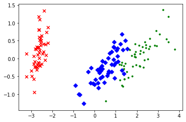

```python
import matplotlib.pyplot as plt
from sklearn.decomposition import PCA
from sklearn.datasets import load_iris
data = load_iris()
y = data.target
x = data.data
#print(type(x))
print(x.shape)
pca = PCA(n_components = 2)
#加载PCA算法，设置降维后主成分数目为2
reduced_x = pca.fit_transform(x)   #对样本进行降维
print(reduced_x)
#在平面中画出降维后的样本点的分布，按照y指定的类别按红蓝绿颜色区分
red_x,red_y = [],[]
blue_x,blue_y = [],[]
green_x,green_y = [],[]
for i in range(len(reduced_x)):
    if y[i] ==0:
        red_x.append(reduced_x[i][0])
        red_y.append(reduced_x[i][1])
    elif y[i]==1:
        blue_x.append(reduced_x[i][0])
        blue_y.append(reduced_x[i][1])
    else:
        green_x.append(reduced_x[i][0])
        green_y.append(reduced_x[i][1])
plt.scatter(red_x,red_y,c='r',marker='x')
plt.scatter(blue_x,blue_y,c='b',marker='D')
plt.scatter(green_x,green_y,c='g',marker='.')
plt.show()
```

## 数据变换与数据离散化

### 数据规范化

【例4-37】数据规范化示例。

```python
import pandas as pd
import numpy as np
a=[47, 83, 81, 18, 72, 41]
b=[56, 96, 84, 21, 87, 67]
data=np.array([a, b]).T
dfab = pd.DataFrame(data, columns=['A', 'B'])
print('最小-最大规范化:\n',(dfab- dfab.min())/(dfab.max()- dfab.min()))
print('零均值规范化：\n',(dfab- dfab.mean())/dfab.std())
```

```
最小-最大规范化:
           A         B
0  0.446154  0.466667
1  1.000000  1.000000
2  0.969231  0.840000
3  0.000000  0.000000
4  0.830769  0.880000
5  0.353846  0.613333
零均值规范化：
           A         B
0 -0.386103 -0.456223
1  1.003868  1.003690
2  0.926648  0.565716
3 -1.505803 -1.733646
4  0.579155  0.675209
5 -0.617765 -0.054747
```

### 类别型数据的哑变量处理

【例4-38】数据的哑变量处理。

```python
df = pd.DataFrame([
            ['green', 'M', 10.1, 'class1'],
            ['red', 'L', 13.5, 'class2'],
            ['blue', 'XL', 14.3, 'class1']])
df.columns = ['color', 'size', 'prize','class label']
print(df)
df1=pd.get_dummies(df)
display(df1)
```

```
   color size  prize class label
0  green    M   10.1      class1
1    red    L   13.5      class2
2   blue   XL   14.3      class1
```

|  | prize | color_blue | color_green | color_red | size_L | size_M | size_XL | class label_class1 | class label_class2 |
| --- | --- | --- | --- | --- | --- | --- | --- | --- | --- |
| 0 | 10.1 | 0 | 1 | 0 | 0 | 1 | 0 | 1 | 0 |
| 1 | 13.5 | 0 | 0 | 1 | 1 | 0 | 0 | 0 | 1 |
| 2 | 14.3 | 1 | 0 | 0 | 0 | 0 | 1 | 1 | 0 |

### 连续型变量的离散化

pandas.cut(x, bins, right=True, labels=None, retbins=False, precision=3 )

x 待离散化的数据. Must be 1-dimensional.

bins 接收int,list,tuple int表示离散化后的类别数目，若为序列表示进行切分的区间，每两个数的间隔为一个区间

right bool, default True Indicates whether bins includes the rightmost edge or not. If right == True (the default), then the bins [1, 2, 3, 4] indicate (1,2], (2,3], (3,4].

labels array or False, default None Specifies the labels for the returned bins.

retbins bool, default False：是否返回区间标签

precision int, default 3：标签的精度

#### 【例4-39】cut方法应用。

```python
np.random.seed(666)
score_list = np.random.randint(25, 100, size = 10)
print('原始数据：\n',score_list)
bins = [0, 59, 70, 80, 100]
score_cut = pd.cut(score_list, bins)
#score_cut = pd.cut(score_list, bins,labels=['A','B','C','D'])
display(pd.value_counts(score_cut),score_cut )
# 统计每个区间人数
```

```
原始数据：
 [27 70 55 87 95 98 55 61 86 76]
```

```
(80, 100]    4
(0, 59]      3
(59, 70]     2
(70, 80]     1
dtype: int64
```

```
[(0, 59], (59, 70], (0, 59], (80, 100], (80, 100], (80, 100], (0, 59], (59, 70], (80, 100], (70, 80]]
Categories (4, interval[int64, right]): [(0, 59] < (59, 70] < (70, 80] < (80, 100]]
```

#### 【例4-40】等频法离散化连续型数据。

```python
def SameRateCut(data,k):
    w = data.quantile(np.arange(0,1+1.0/k,1.0/k)) #输出对应的分位数
    data = pd.cut(data,w) #按分位数序列cut
    return data
result = SameRateCut(pd.Series(score_list),3) #等频、等深 3分
result.value_counts()
```

[output not shown]

```python
pd.Series(score_list).quantile(np.arange(0,1+1.0/2,1.0/2))
```

```
0.0    27.0
0.5    73.0
1.0    98.0
dtype: float64
```

## 利用scikit-learn进行数据预处理

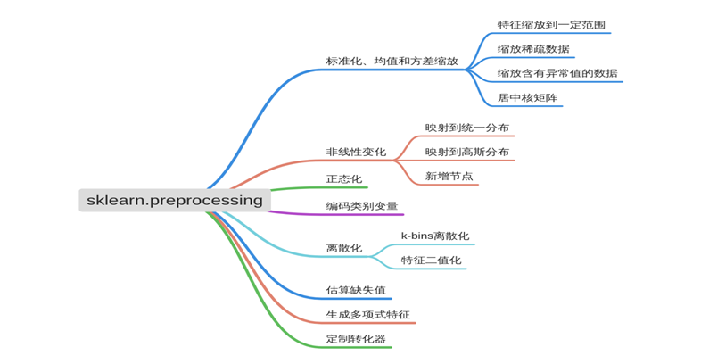

### 数据标准化、均值和方差缩放

#### 【例4-41】数据的标准化、方差和标准差求解示例

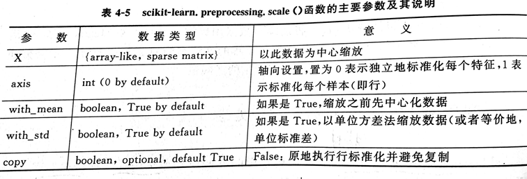

```python
from sklearn import preprocessing
import numpy as np
X_train = np.array([[ 1., -2.,  1.5],[ 2.2,  1.3, 0.5],[ 0.3,  1., -1.5]])
X_scaled = preprocessing.scale(X_train) #scale函数实现标准化
print('X_train:\n',X_train)
print('处理前均值：',X_train.mean(axis=0))
print('处理前单位方差：',X_train.std(axis=0))
print('X_scaled:\n',X_scaled)
print('处理后均值：',X_scaled.mean(axis=0))
print('处理后单位方差：',X_scaled.std(axis=0))
```

```
X_train:
 [[ 1.  -2.   1.5]
 [ 2.2  1.3  0.5]
 [ 0.3  1.  -1.5]]
处理前均值： [1.16666667 0.1        0.16666667]
处理前单位方差： [0.78457349 1.48996644 1.24721913]
X_scaled:
 [[-0.21242964 -1.40942772  1.06904497]
 [ 1.31706379  0.80538727  0.26726124]
 [-1.10463415  0.60404045 -1.33630621]]
处理后均值： [0. 0. 0.]
处理后单位方差： [1. 1. 1.]
```

#### 【例4-42】数据的标准化计算示例。

```python
scaler = preprocessing.StandardScaler().fit(X_train) #用X_train拟合实例化StandardScaler类
print('scaler.scale_ :',scaler.scale_)  #计算训练集标准差
print('scaler.mean_ :',scaler.mean_) #计算训练集均值
scaler.transform(X_train)

#在测试集上使用scaler实例，按照训练集的均值和标准差进行转化
X_test=[[-1.,1.,0.]]
scaler.transform(X_test)
```

```
scaler.scale_ : [0.78457349 1.48996644 1.24721913]
scaler.mean_ : [1.16666667 0.1        0.16666667]
```

```
array([[-2.76158538,  0.60404045, -0.13363062]])
```

### 特征缩放

另一种标准化是特征缩放，使其介于给定的最小最大值之间，通常是0-1之间，或者使每个特征的最大绝对值被缩放到单位大小。

#### 一般特征值缩放

使用MinMaxScaler()或MinAbsScaler()进行。

##### 【例4-43】数据的缩放示例。

```python
X_train = np.array([[ 1., -1.,  2.],[ 2.,  0.,  0.],[ 0.,  1., -1.]])
min_max_scaler = preprocessing.MinMaxScaler()   #实例化or构造模型
X_train_minmax = min_max_scaler.fit_transform(X_train)    #拟合or初始化,归一化到[0,1]之间
print('原数据：\n',X_train)
print('归一化：\n',X_train_minmax)
print('\n',min_max_scaler.scale_)
print('\n',min_max_scaler.min_)

##在测试集上使用min_max_scaler实例，按照训练集的Min和Max进行转化
X_test = np.array([[-3., -1.,  4.]])
X_test_minmax = min_max_scaler.transform(X_test) #按前面拟合好的模型转化X_test
print('\n测试数据：',X_test)
print('归一化的测试数据：\n',X_test_minmax)
print('\n',min_max_scaler.scale_) #scaler.scale_  相对缩放的大小 =（缩放后的最大值-缩放后的最小值）/（原始数据的最大值-原始数据的最小值）
print('\n',min_max_scaler.min_) #scaler.min_  每个特征最小值的调整程度=调整后的最小值-每个特征最小值*相对缩放大小
```

```
原数据：
 [[ 1. -1.  2.]
 [ 2.  0.  0.]
 [ 0.  1. -1.]]
归一化：
 [[0.5        0.         1.        ]
 [1.         0.5        0.33333333]
 [0.         1.         0.        ]]

 [0.5        0.5        0.33333333]

 [0.         0.5        0.33333333]

测试数据： [[-3. -1.  4.]]
归一化的测试数据：
 [[-1.5         0.          1.66666667]]

 [0.5        0.5        0.33333333]

 [0.         0.5        0.33333333]
```

##### 【例4-44】利用MaxAbsScaler将数据归一化。

```python
X_train = np.array([[ 1., -1.,  2.],[ 2.,  0.,  0.],[ 0.,  1., -1.]])
max_Abs_scaler = preprocessing.MaxAbsScaler()  #构造
X_train_minmax = max_Abs_scaler.fit_transform(X_train)   #拟合,按绝对值归一化到[-1,1]之间
print('原数据：\n',X_train)
print('归一化：\n',X_train_minmax)


X_test = np.array([[-3., -1.,  4.]])
X_test_maxAbs = max_Abs_scaler.transform(X_test)  #应用
print('测试数据：',X_test)
print('归一化的测试数据：',X_test_maxAbs)
```

```
原数据：
 [[ 1. -1.  2.]
 [ 2.  0.  0.]
 [ 0.  1. -1.]]
归一化：
 [[ 0.5 -1.   1. ]
 [ 1.   0.   0. ]
 [ 0.   1.  -0.5]]
测试数据： [[-3. -1.  4.]]
归一化的测试数据： [[-1.5 -1.   2. ]]
```

#### 带异常值的缩放数据

##### 补充案例

```python
#from sklearn.preprocessing import RobustScaler
X = [[ 1., -2.,  2.],[ -2.,  1.,  3.],[ 4.,  1., -2.]]
robust_scaler = preprocessing.RobustScaler()  #构造
X_robust = robust_scaler.fit_transform(X)
print('原数据：\n',X )
print('归一化：\n',X_robust)


# transformer = RobustScaler().fit(X)
# transformer
# transformer.transform(X)
```

```
原数据：
 [[1.0, -2.0, 2.0], [-2.0, 1.0, 3.0], [4.0, 1.0, -2.0]]
归一化：
 [[ 0.  -2.   0. ]
 [-1.   0.   0.4]
 [ 1.   0.  -1.6]]
```

### 非线性变换

非线性变换有分位数转换和幂转换。

分位数变换和幂变换都是基于特征的单调变换，从而保持每个特征值的秩。

分位数变换:将所有特征置于相同的期望分布中。

幂变换:将数据从任意分布映射到接近高斯分布的位置。

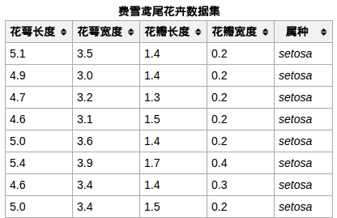

#### 【例4-45】数据映射到值介于0和1之间的均匀分布

https://scikit-learn.org.cn/view/748.html

```python
from sklearn.datasets import load_iris
from sklearn.model_selection import train_test_split
X, y = load_iris(return_X_y=True) #return_X_y控制输出数据的结构，True则将因变量和自变量独立导出；
X_train, X_test, y_train, y_test = train_test_split(X, y, random_state=0) #random_state的值相当于一种规则，通过设定为相同的数，每次分割的结果都是相同的
quantile_transformer = preprocessing.QuantileTransformer(random_state=0) #实例化
X_train_trans = quantile_transformer.fit_transform(X_train)  #用X_train拟合quantile_transformer对象
X_test_trans = quantile_transformer.transform(X_test)   #将quantile_transformer应用到X-test
print(X_train[:, 0].max() )
print(X_train[:, 0].min() )

# 观察特征转换前后的4分位关键点值（此特征对应于以厘米为单位的萼片长度（第1列））。
print(np.percentile(X_train[:, 0], [0, 25, 50, 75, 100]) )

print(np.percentile(X_train_trans[:, 0], [0, 25, 50, 75, 100]))

iris=load_iris()

print(iris.feature_names)
```

```
7.9
4.3
[4.3 5.1 5.8 6.5 7.9]
[0.         0.23873874 0.50900901 0.74324324 1.        ]
['sepal length (cm)', 'sepal width (cm)', 'petal length (cm)', 'petal width (cm)']
```

#### 【例4-46】使用Box-Cox将从对数正态分布绘制的样本映射到正态分布的示例。

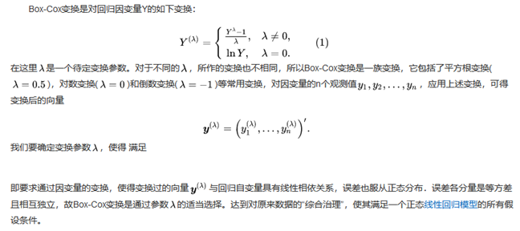

https://scikit-learn.org.cn/view/747.html

class sklearn.preprocessing.PowerTransformer(method='yeo-johnson', *, standardize=True, copy=True)

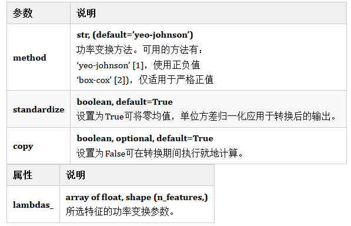

```python
pt = preprocessing.PowerTransformer(method='box-cox', standardize=False)
X_lognormal = np.random.RandomState(616).lognormal(size=(3, 3))
print(X_lognormal)
T=pt.fit_transform(X_lognormal)
print('\n',pt.lambdas_) #展示变换参数
print('\n',T)  #展示幂变换后的数据
```

```
[[1.28331718 1.18092228 0.84160269]
 [0.94293279 1.60960836 0.3879099 ]
 [1.35235668 0.21715673 1.09977091]]

 [4.92011847 0.86296593 1.15354435]

 [[ 0.49024349  0.17881995 -0.1563781 ]
 [-0.05102892  0.58863195 -0.57612414]
 [ 0.69420009 -0.84857822  0.10051454]]
```

#### 【例4-47】使用QuantileTransformer方法进行数据映射。

class sklearn.preprocessing.QuantileTransformer(*, n_quantiles=1000, output_distribution='uniform', ignore_implicit_zeros=False, subsample=100000, random_state=None, copy=True)

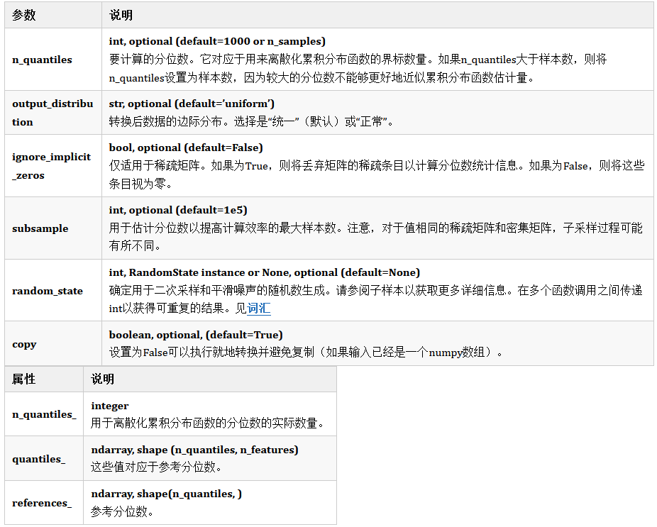

```python
from sklearn.datasets import load_iris
from sklearn.model_selection import train_test_split
X, y = load_iris(return_X_y=True)
quantile_transformer = preprocessing.QuantileTransformer(output_distribution='normal', random_state=0)
X_trans = quantile_transformer.fit_transform(X)
print(quantile_transformer.n_quantiles_)  #分位数实际数量
print(quantile_transformer.quantiles_)  #参考分位数
print(X_trans)
```

```
150
[[4.3 2.  1.  0.1]
 [4.4 2.2 1.1 0.1]
 [4.4 2.2 1.2 0.1]
 [4.4 2.2 1.2 0.1]
 [4.5 2.3 1.3 0.1]
 [4.6 2.3 1.3 0.2]
 [4.6 2.3 1.3 0.2]
 [4.6 2.3 1.3 0.2]
 [4.6 2.4 1.3 0.2]
 [4.7 2.4 1.3 0.2]
 [4.7 2.4 1.3 0.2]
 [4.8 2.5 1.4 0.2]
 [4.8 2.5 1.4 0.2]
 [4.8 2.5 1.4 0.2]
 [4.8 2.5 1.4 0.2]
 [4.8 2.5 1.4 0.2]
 [4.9 2.5 1.4 0.2]
 [4.9 2.5 1.4 0.2]
 [4.9 2.5 1.4 0.2]
 [4.9 2.6 1.4 0.2]
 [4.9 2.6 1.4 0.2]
 [4.9 2.6 1.4 0.2]
 [5.  2.6 1.4 0.2]
 [5.  2.6 1.4 0.2]
 [5.  2.7 1.5 0.2]
 [5.  2.7 1.5 0.2]
 [5.  2.7 1.5 0.2]
 [5.  2.7 1.5 0.2]
 [5.  2.7 1.5 0.2]
 [5.  2.7 1.5 0.2]
 [5.  2.7 1.5 0.2]
 [5.  2.7 1.5 0.2]
 [5.1 2.7 1.5 0.2]
 [5.1 2.8 1.5 0.2]
 [5.1 2.8 1.5 0.3]
 [5.1 2.8 1.5 0.3]
 [5.1 2.8 1.5 0.3]
 [5.1 2.8 1.6 0.3]
 [5.1 2.8 1.6 0.3]
```

[output cut: 246 more lines]

```
 [ 2.0509845  -0.08421448  1.71009492  1.52396771]
 [ 0.50901993  0.82495705  1.06121852  1.87784272]
 [ 0.65873319  0.22909903  0.94966622  0.62769869]
 [ 0.18612212 -0.08421448  0.37898637  0.62769869]
 [ 1.29700091  0.22909903  0.86910908  1.12227633]
 [ 1.01790137  0.22909903  1.06121852  1.87784272]
 [ 1.29700091  0.22909903  0.66921913  1.52396771]
 [ 0.02523719 -0.88558921  0.66921913  0.81319305]
 [ 1.17097024  0.44306583  1.42429043  1.52396771]
 [ 1.01790137  0.62769869  1.20503985  5.19933758]
 [ 1.01790137 -0.08421448  0.77855548  1.52396771]
 [ 0.50901993 -1.29700091  0.54770771  0.81319305]
 [ 0.77855548 -0.08421448  0.77855548  0.94966622]
 [ 0.37898637  0.82495705  0.86910908  1.52396771]
 [ 0.10956839 -0.08421448  0.66921913  0.62769869]]
```

### 正则化/归一化

https://scikit-learn.org.cn/view/123.html#6.3.3%20%20%E5%BD%92%E4%B8%80%E5%8C%96

正则化与归一化的区分：https://www.cnblogs.com/hanhanzhu000/p/4159833.html

【例4-48】数据正则化示例

```python
X = [[ 1., -1.,  2.],[ 2.,  0.,  0.],[ 0.,  1., -1.]]
X_normalized = preprocessing.normalize(X, norm='l2')
X_normalized
```

```
array([[ 0.40824829, -0.40824829,  0.81649658],
       [ 1.        ,  0.        ,  0.        ],
       [ 0.        ,  0.70710678, -0.70710678]])
```

### 编码分类特征

#### 【例4-49】数据编码示例。

https://scikit-learn.org.cn/view/744.html

使用OrdinalEncoder将每个范畴特征转换为整数。

class sklearn.preprocessing.OrdinalEncoder(*, categories='auto', dtype=<class 'numpy.float64'>)

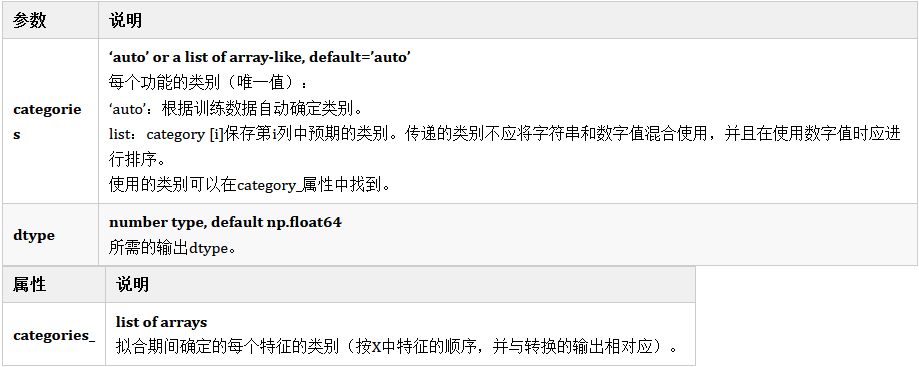

```python
enc = preprocessing.OrdinalEncoder()
X = [['male', 'from US', 'uses Safari'], ['female', 'from Europe', 'uses Firefox']]
Y=enc.fit(X)
print(enc.transform([['female', 'from US', 'uses Safari']]))
print(Y.categories_) #给出拟合期间确定的每个特征的类别
enc.inverse_transform([[0., 1., 1.]])
```

```
[[0. 1. 1.]]
[array(['female', 'male'], dtype=object), array(['from Europe', 'from US'], dtype=object), array(['uses Firefox', 'uses Safari'], dtype=object)]
```

```
array([['female', 'from US', 'uses Safari']], dtype=object)
```

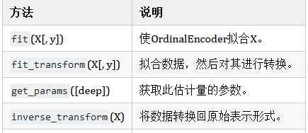

但是，此类整数表示不能直接在所有的scikit-learn估计器使用，因为这样连续型数值的输入，估计器会将类别解释为有序的，而通常是无序的（例如，浏览器的类别数据是任意无序的）。

#### 【例5-50】使用OneHotEncoder进行分类特征编码示例。

将分类特征转换为可与scikit-learn估计器一起使用的特征的另一种方法是使用one-of-K，也称为**独热或伪编码**。这种类型的编码可以通过OneHotEncoder来获得，它将具有n_categories个可能值的每个分类特征转换为n_categories个二进制特征，其中一个位置为1，所有其他位置为0。

```python
enc = preprocessing.OneHotEncoder()
X = [['male', 'from US', 'uses Safari'], ['female', 'from Europe', 'uses Firefox']]
enc.fit(X)
R=enc.transform([['female', 'from US', 'uses Safari'],['male', 'from Europe', 'uses Safari']]).toarray()
display(R)
print(enc.categories_)
```

```
array([[1., 0., 0., 1., 0., 1.],
       [0., 1., 1., 0., 0., 1.]])
```

```
[array(['female', 'male'], dtype=object), array(['from Europe', 'from US'], dtype=object), array(['uses Firefox', 'uses Safari'], dtype=object)]
```

#### 【例4-51】类型数据变换示例，数据集中有两种性别，四个可能的大洲和四个网络浏览器。

```python
genders = ['female', 'male']
locations = ['from Africa', 'from Asia', 'from Europe', 'from US']
browsers = ['uses Chrome', 'uses Firefox', 'uses IE', 'uses Safari']
enc = preprocessing.OneHotEncoder(categories=[genders, locations, browsers]) #可以使用参数categories显式的指定，我们的数据集中有两种性别，四个可能的大陆和四个Web浏览器：
X = [['male', 'from US', 'uses Safari'], ['female', 'from Europe', 'uses Firefox']]
enc.fit(X)
enc.transform([['female', 'from Asia', 'uses Chrome']]).toarray()
```

```
array([[1., 0., 0., 1., 0., 0., 1., 0., 0., 0.]])
```

### 离散化

#### 【例4-52】：数据的K-桶离散化示例。

class sklearn.preprocessing.KBinsDiscretizer(n_bins=5, *, encode='onehot', strategy='quantile')

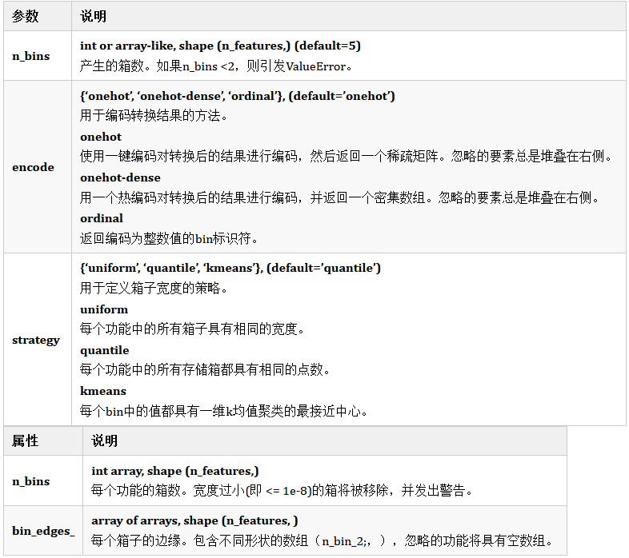

```python
X = np.array([[ -3., 5., 15 ],[  0., 6., 14 ],[  6., 3., 11 ]])
est = preprocessing.KBinsDiscretizer(n_bins=[3, 2, 2], encode='ordinal').fit(X)
print(est.transform(X))
print(est.n_bins)
print(est.bin_edges_)
print(est.transform([[  -4., 5., 18]] ))
```

```
[[0. 1. 1.]
 [1. 1. 1.]
 [2. 0. 0.]]
[3, 2, 2]
[array([-3., -1.,  2.,  6.]) array([3., 5., 6.]) array([11., 14., 15.])]
[[0. 1. 1.]]
```

#### 【例4-53】数据的二值化示例。

class sklearn.preprocessing.Binarizer(*, threshold=0.0, copy=True)

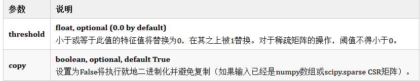

```python
X = [[ 1., -1.,  2.],[ 2.,  0.,  0.],[ 0.,  1., -1.]]
binarizer = preprocessing.Binarizer().fit(X)
Y1=binarizer.transform(X)
print(Y1)
# 可以调整阈值
binarizer = preprocessing.Binarizer(threshold=1.1)
Y2=binarizer.transform(X)
print(Y2)
```

```
[[1. 0. 1.]
 [1. 0. 0.]
 [0. 1. 0.]]
[[0. 0. 1.]
 [1. 0. 0.]
 [0. 0. 0.]]
```

#### 缺失值的填充

【例4-54】

sklearn中的绝大部分模型都不能自动处理缺失值（树模型除外），必须进行预处理。

```
方法一：删除缺失值所在的整行或整列，代价是信息丢失

方法二：使用所在行/列中的平均值、中位数或者众数来填充缺失值，代价是引入偏差
```

class sklearn.impute.SimpleImputer(

```
missing_values = 'NaN' : integer or 'NaN', 缺失值在数据中的表示方法
strategy = 'mean' : 填充方法，'mean', 'median', 'most_frequent', 'constant'
fill_value = None : 当strategy == “constant”时，提供替代NA的值
None时，数值填0，其余填NA
axis = 0 : integer, 按照列(0)还是行(1)进行填充
verbose = 0 : integer, 控制填充的冗余度,很少修改
copy = True :
add_indicator = False : 是否输出指示NA位置的 MissingIndicator
```

)

SimpleImputer类的属性：

statistics_ : array of shape (n*features,)，按列填充时各属性的填充值 indicator* : MissingIndicator，add_indicator = False时为None

```python
from sklearn.impute import SimpleImputer
# 老版本写法：from sklearn.preprocessing import Imputer
import numpy as np

imp = SimpleImputer()
imp.fit([[1, 2],
         [np.nan, 3],
         [7, 6]]) #按这里的2*3数组的列的特性fit 模型
imp.transform([[np.nan, 2],
               [6, np.nan]]) #按前面学的的 填充新数组的缺失值，第一列均值为4，第二列均值为3.67
```

```
array([[4.        , 2.        ],
       [6.        , 3.66666667]])
```

```python
imp.statistics_
```

```
array([4.        , 3.66666667])
```

## 过采样和欠采样

### 过采样

```python
#pip install --user imblearn
```

```python
import pandas as pd
data = pd.read_excel("信用卡数据.xlsx")
data.head()
```

|  | 编号 | 年龄 | 负债比率 | 月收入 | 贷款数量 | 家属人数 | 分类 |
| --- | --- | --- | --- | --- | --- | --- | --- |
| 0 | 1 | 29 | 0.22 | 7800 | 1 | 3 | 0 |
| 1 | 2 | 52 | 0.46 | 4650 | 1 | 0 | 0 |
| 2 | 3 | 28 | 0.10 | 3000 | 0 | 0 | 0 |
| 3 | 4 | 29 | 0.20 | 5916 | 0 | 0 | 0 |
| 4 | 5 | 27 | 1.28 | 1300 | 0 | 0 | 1 |

```python
# 通过如下代码提取特征变量并将其赋值给变量X，提取目标变量并将其赋值给变量y：。
X = data.drop(columns='分类')
y = data['分类']
```

```python
# 然后使用collections库中的Counter()方法，对目标变量进行计数：
from collections import Counter
Counter(y)
```

```
Counter({0: 1000, 1: 100})
```

不违约的样本数有1000个，远远大于违约的样本数100。为了防止建立信用违约模型时，模型着重拟合不违约的样本，而无法找出违约的样本，我们采用过采样的方法来改善样本比例不均衡的问题，这里我们将通过上面讲到的随机过采样和SMOTE法过采样来进行代码实现。

（1）随机过采样

```python
from imblearn.over_sampling import RandomOverSampler
ros = RandomOverSampler(random_state=0)
X_oversampled, y_oversampled = ros.fit_resample(X, y)
```

```python
# 用Counter()方法检验一下SMOTE过采样的效果。
Counter(y_oversampled)
```

```
Counter({0: 1000, 1: 1000})
```

违约的样本数从100上升至不违约的样本数1000，这证明我们的随机过采样有效。同时我们可以打印特征变量X_oversampled的shape来看看特征变量的变化：

```python
X_oversampled.shape
```

```
(2000, 6)
```

这里的2000就是1000个违约样本和1000个不违约样本相加得到的，可以看到，随机过采样后特征变量的数据也随之增多。

（2）SMOTE过采样

```python
# 通过如下代码即可进行SMOTE过采样：
from imblearn.over_sampling import SMOTE
smote = SMOTE(random_state=0)
X_smotesampled, y_smotesampled = smote.fit_resample(X, y)
```

```python
# 用Counter()方法检验一下SMOTE过采样的效果。
Counter(y_smotesampled)
```

```
Counter({0: 1000, 1: 1000})
```

### 欠采样

```python
# 仍然采用上方的信用违约数据进行欠采样代码的展示：
from imblearn.under_sampling import RandomUnderSampler
rus = RandomUnderSampler(random_state=0)
X_undersampled, y_undersampled = rus.fit_resample(X, y)
```

```python
# 用Counter()方法检验一下随机欠采样的效果。
Counter(y_undersampled)
```

```
Counter({0: 100, 1: 100})
```

```python
# 不违约的样本数从1000下降至违约的样本数100，这证明我们的随机欠采样有效。同时我们可以打印特征变量X_undersampled的shape来看看特征变量的变化：
X_undersampled.shape
```

```
(200, 6)
```

## 练习题

P135 （3）